# Regression and model validation

11 Nov 2018

# Regression and model validation (Week 2)

## Read Data

```r
analysis_data <- read.csv("~/Documents/GitHub/IODS-project/data/learning2014.csv",
                    sep=",", header=TRUE)
```

## Description of data

```r
str(analysis_data)
```

```
## 'data.frame':    166 obs. of  7 variables:
##  $ gender  : Factor w/ 2 levels "F","M": 1 2 1 2 2 1 2 1 2 1 ...
##  $ age     : int  53 55 49 53 49 38 50 37 37 42 ...
##  $ attitude: int  37 31 25 35 37 38 35 29 38 21 ...
##  $ deep    : num  0.97 0.789 0.947 0.947 0.992 ...
##  $ stra    : num  0.314 0.256 0.307 0.307 0.322 ...
##  $ surf    : num  0.925 1.134 0.806 0.806 1.015 ...
##  $ points  : int  25 12 24 10 22 21 21 31 24 26 ...
```

#### The dataset contains a total of 166 observations with 7 variables like gender, age, attitude score and other questions.

```r
dim(analysis_data)
```

```
## [1] 166   7
```

#### The above command returns the exact dimensions of the dataset we have. The dataset confirms that there are 166 rows with 7 columns containing the variables.

## Overview of the dataset

### Variable summaries

```r
summary(analysis_data$gender)
```

```
##   F   M
## 110  56
```

```r
summary(analysis_data$age)
```

```
##    Min. 1st Qu.  Median    Mean 3rd Qu.    Max.
##   17.00   21.00   22.00   25.51   27.00   55.00
```

```r
summary(analysis_data$attitude)
```

```
##    Min. 1st Qu.  Median    Mean 3rd Qu.    Max.
##   14.00   26.00   32.00   31.43   37.00   50.00
```

```r
summary(analysis_data$deep)
```

```
##    Min. 1st Qu.  Median    Mean 3rd Qu.    Max.
##  0.4284  0.9019  0.9921  0.9956  1.1049  1.3303
```

```r
summary(analysis_data$stra)
```

```
##    Min. 1st Qu.  Median    Mean 3rd Qu.    Max.
##  0.1389  0.2923  0.3216  0.3227  0.3581  0.4312
```

```r
summary(analysis_data$surf)
```

```
##    Min. 1st Qu.  Median    Mean 3rd Qu.    Max.
##  0.5670  0.8655  1.0147  0.9981  1.1341  1.5519
```

```r
summary(analysis_data$points)
```

```
##    Min. 1st Qu.  Median    Mean 3rd Qu.    Max.
##    7.00   19.00   23.00   22.72   27.75   33.00
```

#### There are 110 females compared to 56 males in this dataset. The distribution of ages of students are from 17 to 55, with an average age of 25.51 years. Majority of students (upto 3rd quartile) are below 30 years, making the variable heavily skewed.To look at how these different variables could be inter-related, we plot a plot below.

### Load the GGally and ggplot2 libraries

```r
library(GGally)
```

```r
library(ggplot2)
```

### Create plot matrix

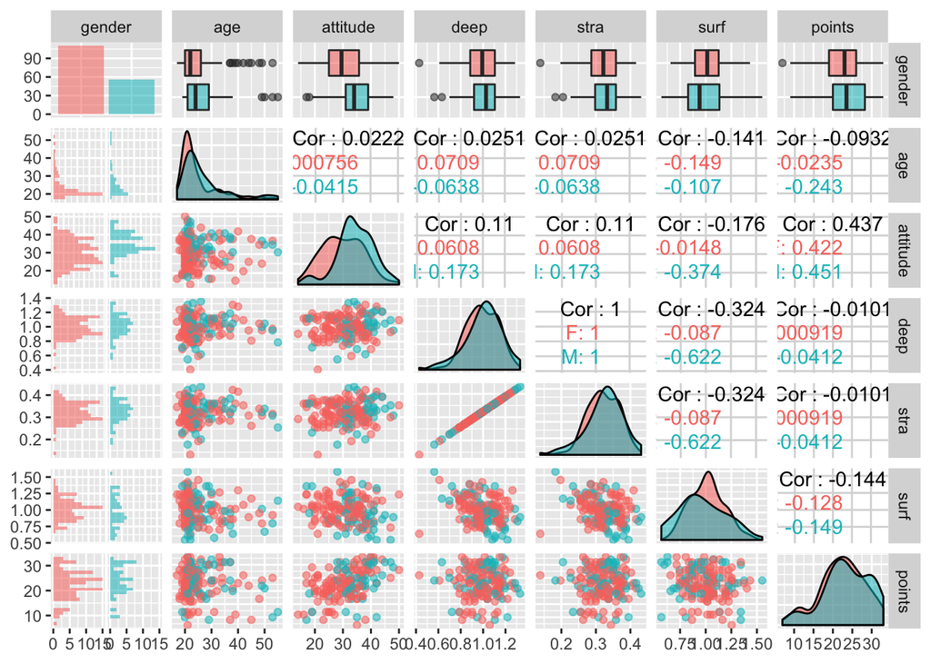

```r
ggpairs(analysis_data, mapping = aes( col = gender, alpha = 0.2 ), lower = list(combo = wrap("facethist", bins = 20)))
```

#### We see an interesting set of inter-relationships amongst the variables ranging from positive to negative correlation. However, all these relationships are seen here one-to-one, which is biased, since the final scores are dependent on various variables and hence a linear model needs to be developed to investigate this.

## Regression Model

### Create a regression model with multiple explanatory variables

```r
my_model <- lm(points ~ attitude + age + stra, data = analysis_data)
```

### Summary of the model

```r
summary(my_model)
```

```
##
## Call:
## lm(formula = points ~ attitude + age + stra, data = analysis_data)
##
## Residuals:
##     Min      1Q  Median      3Q     Max
## -17.206  -3.430   0.204   3.979  10.950
##
## Coefficients:
##             Estimate Std. Error t value Pr(>|t|)
## (Intercept) 15.60773    3.38966   4.605 8.32e-06 ***
## attitude     0.35941    0.05696   6.310 2.56e-09 ***
## age         -0.07716    0.05322  -1.450    0.149
## stra        -6.87318    8.55576  -0.803    0.423
## ---
## Signif. codes:  0 '***' 0.001 '**' 0.01 '*' 0.05 '.' 0.1 ' ' 1
##
## Residual standard error: 5.307 on 162 degrees of freedom
## Multiple R-squared:  0.2043, Adjusted R-squared:  0.1896
## F-statistic: 13.87 on 3 and 162 DF,  p-value: 4.305e-08
```

#### We see here that attitude is highly associated with the dependent variable, exam points as evidenced by the highly significant p-value of 2.56e-09, much less than the alpha level of 0.05.

#### Interestingly, Age and strategic questions have negative beta values.

### Create a regression model with non-significant variables removed

```r
my_model2 <- lm(points ~  attitude, data = analysis_data)
```

### Summary of the new model

```r
summary(my_model2)
```

```
##
## Call:
## lm(formula = points ~ attitude, data = analysis_data)
##
## Residuals:
##      Min       1Q   Median       3Q      Max
## -16.9763  -3.2119   0.4339   4.1534  10.6645
##
## Coefficients:
##             Estimate Std. Error t value Pr(>|t|)
## (Intercept) 11.63715    1.83035   6.358 1.95e-09 ***
## attitude     0.35255    0.05674   6.214 4.12e-09 ***
## ---
## Signif. codes:  0 '***' 0.001 '**' 0.01 '*' 0.05 '.' 0.1 ' ' 1
##
## Residual standard error: 5.32 on 164 degrees of freedom
## Multiple R-squared:  0.1906, Adjusted R-squared:  0.1856
## F-statistic: 38.61 on 1 and 164 DF,  p-value: 4.119e-09
```

## Summary of fitted model

#### In the initial model, with attitude, age and stra variables, we see that these three variables taken together explain 18.96% of the exam points (Adjusted R-squared: 0.1896)

#### However, attitude variable explains 18.56% of the exam points (Adjusted R-squared: 0.1856), which is little bit lesser than the previous model.

## Model Diagnostics

### Diagnostic plots using the plot() function. We plot these: Residuals vs Fitted values, Normal QQ-plot and Residuals vs Leverage

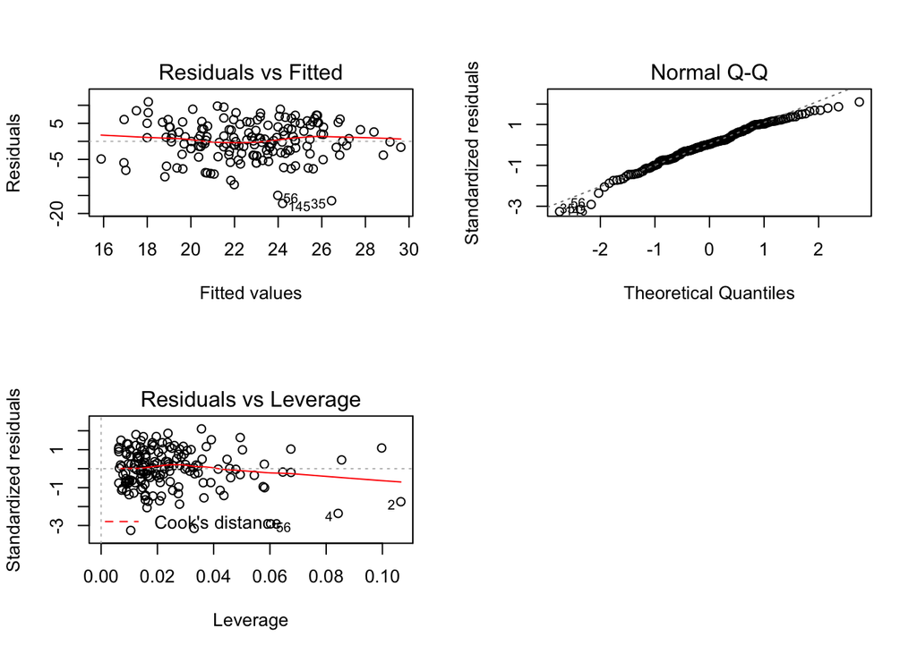

```r
par(mfrow = c(2,2))
plot(my_model, which = c(1, 2, 5))
```

#### To investigate this better, we could exclude obsevrations 2, 4 and 56, and then re-run the analysis again.

### New Model to understand the influence of influential observations

```r
analysis_data_new <- analysis_data[-c(2, 4, 56), ]
my_model3 <- lm(points ~ attitude + age + stra, data = analysis_data_new)
summary(my_model3)
```

```
##
## Call:
## lm(formula = points ~ attitude + age + stra, data = analysis_data_new)
##
## Residuals:
##      Min       1Q   Median       3Q      Max
## -16.8988  -3.4558   0.0807   3.8415  11.5969
##
## Coefficients:
##              Estimate Std. Error t value Pr(>|t|)
## (Intercept)  14.30158    3.21710   4.445 1.64e-05 ***
## attitude      0.38062    0.05399   7.049 5.18e-11 ***
## age           0.04040    0.05658   0.714    0.476
## stra        -13.31399    8.20912  -1.622    0.107
## ---
## Signif. codes:  0 '***' 0.001 '**' 0.01 '*' 0.05 '.' 0.1 ' ' 1
##
## Residual standard error: 5.01 on 159 degrees of freedom
## Multiple R-squared:  0.2415, Adjusted R-squared:  0.2271
## F-statistic: 16.87 on 3 and 159 DF,  p-value: 1.455e-09
```